# Part II - Prosper Loan Data

## by Chinelo Cynthia Ezenwafor

## Investigation Overview

> For this presentation, some of the main insights gotten after the analysis would be displayed. The main purpose is to determine if people borrow money within their income range, and observe how loan amount taken and prosper ratings influence a borrower's annual percentage rate

## Dataset Overview

> The prosper loan dataset contains information about 120,000 loaners that patronise prosper loans. It contains information stored in 81 variables about these customers. Data dictionary to undertsand the variables more can be found [here](https://docs.google.com/spreadsheets/d/1gDyi_L4UvIrLTEC6Wri5nbaMmkGmLQBk-Yx3z0XDEtI/edit#gid=0)

### Main reasons people take a loan

> People have various reasons for needing to take loans and our Prosper loan clients aren't any different. Analysis of listing category of the propser loan clients gives us insight on why they decide to take loans.

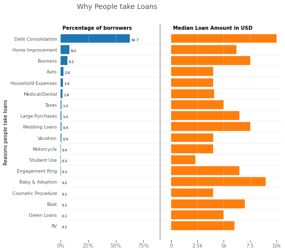

### Main reasons people take a loan

> From the plot, 62.7% of the borrowers take loans to pay off existing loans up to the tune of over 10k dollars. Also, it can be seen that people take huge loans to finance things like weddings, baby and adoption and engagement ring. 6.2% of the borrowers take up to 7.5k dollars loans to finance their business.

### Do people borrow money within their income range?

> It is advisable to keep a debt to income ratio of less than or equal to 0.43. A debt to income ratio greater than 0.5 means the borrower is taking more loans than his income can comfortably offset.

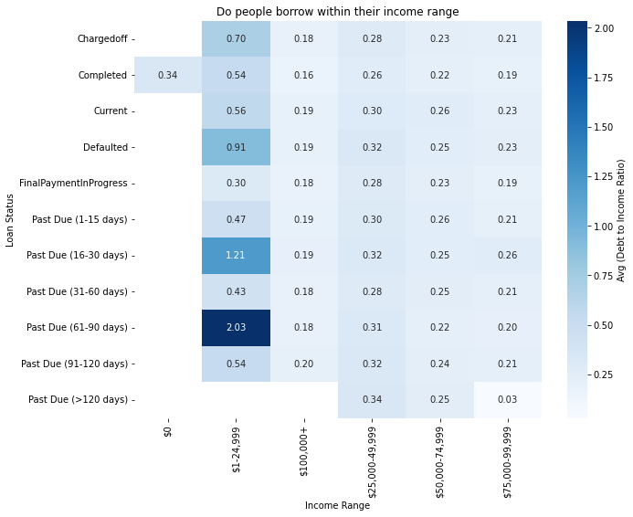

> From the plot, it can be obseved that borrowers who earn between 1-24.999k dollars, tend to have high debt to income ratio(>= 0.5), it can also be seen that majority of these group are owing loans past their due date. Borrowers who earn from 25k and above, tend to keep their loan appropriate to their income.

### Do loan amount taken and prosper ratings influence a borrower's annual percentage rate?

> To analyse the difference in borrowing power between high-rated and low rated borrowers, and the influence the amount of loan taken has on the loan interest.

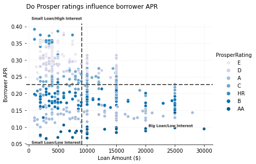

> From the plot, we can observe the relationship between the three variables. Borrowers with high prosper ratings are opportuned to take loans (both large and small) at lower interest rates, while borrowers with low prosper ratings mostly take smaller loans but get higher interest rates.